# Voting & Income Final Report

Kendra Lyons

12/10/2021

# Introduction

Recent Census and polling data confirms that there is a disparity in voting between low-income and high-income citizens. There is a clear positive relationship between voting and income. Simply put, people with less money are less inclined to vote, and vice versa. The same data can give us insight into why this is the case, since the U.S. Census Bureau and polling organizations like FiveThirtyEight include questions about why people don’t vote, as well as how they feel about political institutions in general. Analysis of such data is invaluable for understanding what prevents lower income people from voting and how we as a society can enact policy changes that make democratic participation more accessible to people of all income levels. The primary research questions guiding this project are: 1) How do voting patterns differ according to income level? and 2) What factors prevent low income citizens from voting as often as high income citizens do?

# Data

Data from two sources, the U.S. Census Bureau and FiveThirtyEight, were central to this project. Table 7, entitled “Reported Voting and Registration of Family Members, by Age and Family Income”, and Table 10, entitled “Reasons For Not Voting, By Selected Characteristics” from the U.S. Census Bureau’s 2020 Current Population Survey were both used, and can be freely accessed on their website at: https://www.census.gov/data/tables/time-series/demo/voting-and-registration/p20-585.html. From Table 7, only the data on all adults (rows 8-18) was selected, since, at this time, how age influences voting and registration is not being studied. Rather, this project is primarily focused on how household income affects voting and registration. For the same reason, only the data from Table 10 that is broken down by income (rows 36-47) was selected for analysis. Census data was aggregated by income bracket and both raw numbers (in thousands) and percentages were included. Respondents were asked whether they were registered to vote, whether they voted, and if they reported not voting, what the reason was.

Data from a FiveThirtyEight & Ipsos poll conducted in September 2020 was obtained from their GitHub repository “non-voters”, located at: https://github.com/fivethirtyeight/data/tree/master/non-voters. These data were collected and used for a story published on October 26, 2020 entitled “Why Many Americans Don’t Vote”. Specifically, questions analyzed asked people whether “traditional parties and politicians” cared about people like them, how easy they considered voting in national elections to be, the importance of the results of the 2020 presidential election, how frequently they vote and more. Data were also collected on income, education, voting frequency and more. According to the readme attached to the Git repository, these data came from “5,239 respondents who matched to the voter file and whose verified vote history we have, and 597 respondents who did not match to the voter file and described themselves as voting”rarely” or “never,” all of whom have been eligible for at least 4 elections”

This researcher’s goals in selecting this data were to explore and highlight the relationships between income and election participation, but education is also taken into account in the statistical analysis. Income and Education can be seen as two aspects of class, both of which can influence a citizen’s decision to vote. This is important from a policy standpoint because understanding why voters do and don’t vote and what socioeconomic factors may influence their decisions can help activists, canvassers, advocacy organizations, political parties and governments increase voter turnout. Identifying demographics with lower levels of voting can also encourage policymakers to craft policy that benefits such populations, which is likely to encourage their democratic participation and personal investment in our political system.

For more information about the data, please refer to the following:

- https://github.com/fivethirtyeight/data/tree/master/non-voters#readme
- https://www.census.gov/topics/public-sector/voting/about.html

# Visualization

## Census Data

Read in and inspect data.

```r
voters_by_income <- read_csv("data/census_voters_all_incomes_tidy.csv")
glimpse(voters_by_income)
```

```
## Rows: 10
## Columns: 18
## $ ...1                             <dbl> 1, 2, 3, 4, 5, 6, 7, 8, 9, 10
## $ family_income                    <chr> "Under $10,000", "$10,000 to $14,999"~
## $ total_pop                        <dbl> 3083, 3359, 3327, 9142, 12794, 9948, ~
## $ total_citizens                   <dbl> 2571, 2762, 2833, 7774, 10829, 8637, ~
## $ registered_total                 <dbl> 1523, 1745, 1637, 5124, 7637, 6616, 1~
## $ registered_percent               <dbl> 59.2, 63.2, 57.8, 65.9, 70.5, 76.6, 7~
## $ not_registered_total             <dbl> 629, 645, 787, 1661, 1848, 1182, 2814~
## $ not_registered_percent           <dbl> 24.5, 23.4, 27.8, 21.4, 17.1, 13.7, 1~
## $ no_response_registration_total   <dbl> 419, 371, 409, 989, 1345, 838, 2204, ~
## $ no_response_registration_percent <dbl> 16.3, 13.4, 14.4, 12.7, 12.4, 9.7, 9.~
## $ voted_total                      <dbl> 1212, 1392, 1412, 4357, 6832, 5923, 1~
## $ voted_percent                    <dbl> 47.1, 50.4, 49.8, 56.1, 63.1, 68.6, 7~
## $ not_voted_total                  <dbl> 997, 1011, 1048, 2475, 2708, 1939, 44~
## $ not_voted_percent                <dbl> 38.8, 36.6, 37.0, 31.8, 25.0, 22.4, 1~
## $ no_response_voted_total          <dbl> 362, 358, 374, 942, 1290, 774, 2082, ~
## $ no_response_voted_percent        <dbl> 14.1, 13.0, 13.2, 12.1, 11.9, 9.0, 8.~
## $ total_pop_registered_percent     <dbl> 49.4, 52.0, 49.2, 56.0, 59.7, 66.5, 7~
## $ total_pop_voted_percent          <dbl> 39.3, 41.5, 42.4, 47.7, 53.4, 59.5, 6~
```

```r
all_nonvoters <- read_csv("data/all_nonvoter_reasons_tidy.csv")
glimpse(all_nonvoters)
```

```
## Rows: 12
## Columns: 4
## $ ...1    <dbl> 1, 2, 3, 4, 5, 6, 7, 8, 9, 10, 11, 12
## $ income  <chr> "Total in families", "Total in families", "Total in families",~
## $ reason  <chr> "Out of town", "Forgot to vote", "Concerns about COVID-19", "I~
## $ percent <dbl> 6.3, 3.5, 4.4, 12.6, 17.6, 13.7, 2.1, 14.1, 5.0, 2.6, 15.0, 3.1
```

```r
nonvoters_by_income <- read_csv("data/nonvoter_reasons_by_income_tidy.csv")
glimpse(nonvoters_by_income)
```

```
## Rows: 100
## Columns: 4
## $ ...1    <dbl> 1, 2, 3, 4, 5, 6, 7, 8, 9, 10, 11, 12, 13, 14, 15, 16, 17, 18,~
## $ income  <chr> "<10K", "<10K", "<10K", "<10K", "<10K", "<10K", "<10K", "<10K"~
## $ reason  <chr> "Out of town", "Forgot to vote", "Concerns about COVID-19", "I~
## $ percent <dbl> 6.5, 5.2, 2.9, 15.9, 9.9, 12.6, 6.2, 8.6, 2.8, 6.6, 0.8, 2.2, ~
```

### Reported Voting by Income

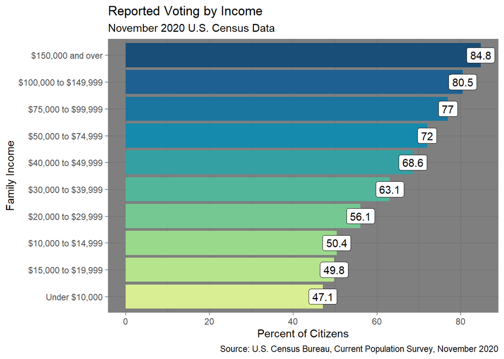

```r
# make palette
palette10 <- c("#d9ed92","#b5e48c","#99d98c","#76c893","#52b69a",
               "#34a0a4","#168aad","#1a759f","#1e6091","#184e77")
# barplot of percentage of (reported) voters by family income
voters_by_income %>%
  ggplot(aes(x=voted_percent, y=reorder(family_income, voted_percent)))+
  geom_col(aes(fill=reorder(family_income, voted_percent)), show.legend = FALSE)+
  geom_label(aes(label=voted_percent))+
  labs(title="Reported Voting by Income",
       subtitle="November 2020 U.S. Census Data",
       caption="Source: U.S. Census Bureau, Current Population Survey, November 2020")+
  xlab("Percent of Citizens")+
  ylab("Family Income")+
  scale_fill_manual(values=palette10) +
  theme_dark()
```

*Figure 1*

### Nonvoter Reasons, All Incomes

Figure 2 gives an overview of the general non-voting (registered) population in 2020 to explore what reasons registered citizens gave for not voting, regardless of income. This plot helps answer why people of all income levels say they don’t vote. Subsequent plots will visualize the differences in reasons given by nonvoters with different incomes. Overall, lack of interest, not liking candidates or campaign issues, busy schedules and illness or disability were the most common reported reasons for not voting.

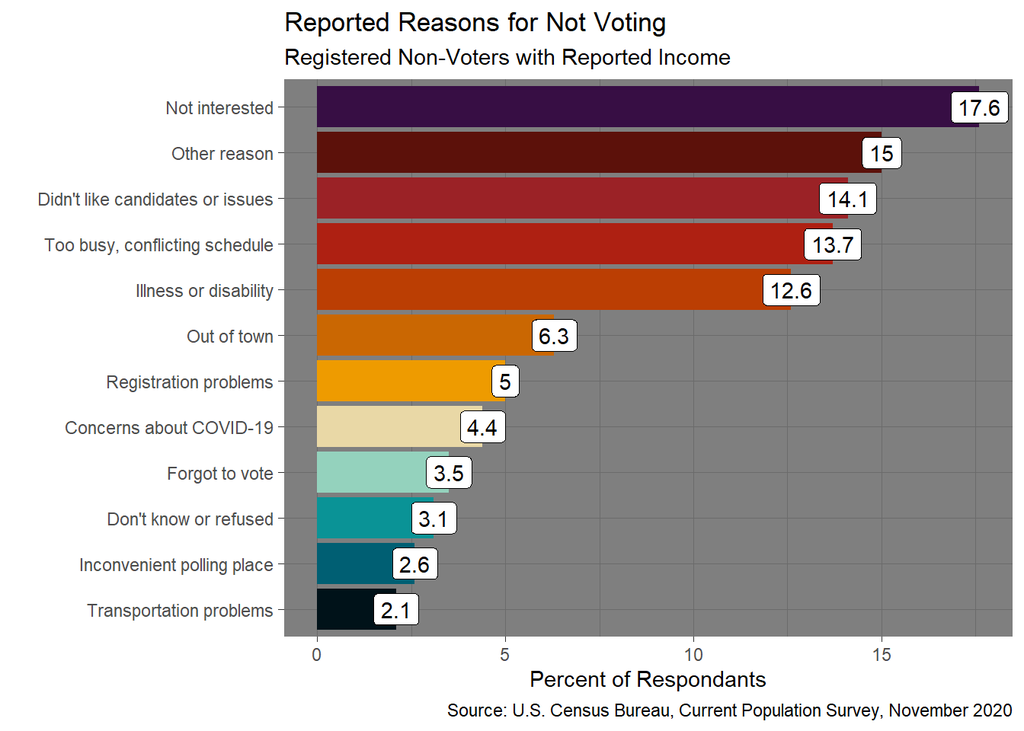

```r
palette12 <- c("#001219","#005f73","#0a9396","#94d2bd","#e9d8a6","#ee9b00","#ca6702",
                 "#bb3e03","#ae2012","#9b2226", "#5c110a", "#370E44")
all_nonvoters %>%
ggplot(aes(x = percent,
           y = reorder(reason, percent)))+
  geom_col(aes(fill = reorder(reason, percent)), show.legend = FALSE)+
  labs(title="Reported Reasons for Not Voting",
       subtitle = "Registered Non-Voters with Reported Income",
       x="Percent of Respondants", y="",
       caption="Source: U.S. Census Bureau, Current Population Survey, November 2020")+
  geom_label(aes(label=percent)) +
  scale_fill_manual(values = palette12) +
  theme_dark()
```

*Figure 2*

### Nonvoter Reasons by Income

Figure 3 visualizes reported reasons for not voting across income, demonstrating that the lowest income voters were more likely not to vote due to barriers like disability or illness, transportation issues or inconvenient polling locations. In contrast, higher income voters were more likely not to vote due to busy schedules, traveling, or not liking candidates or campaign issues. However, disinterest or not liking candidates or campaign issues were reasons commonly given by people at *all income levels*, suggesting a broad crisis of faith in the U.S. political system. Notably, disability or illness and conflicting schedules were also among the top reasons for not voting overall. Both of these can be ameliorated in the future by providing early and mail-in ballot access to people of all income levels, and by making polling places much more accessible to low income people, particularly those with disabilities and transportation barriers.

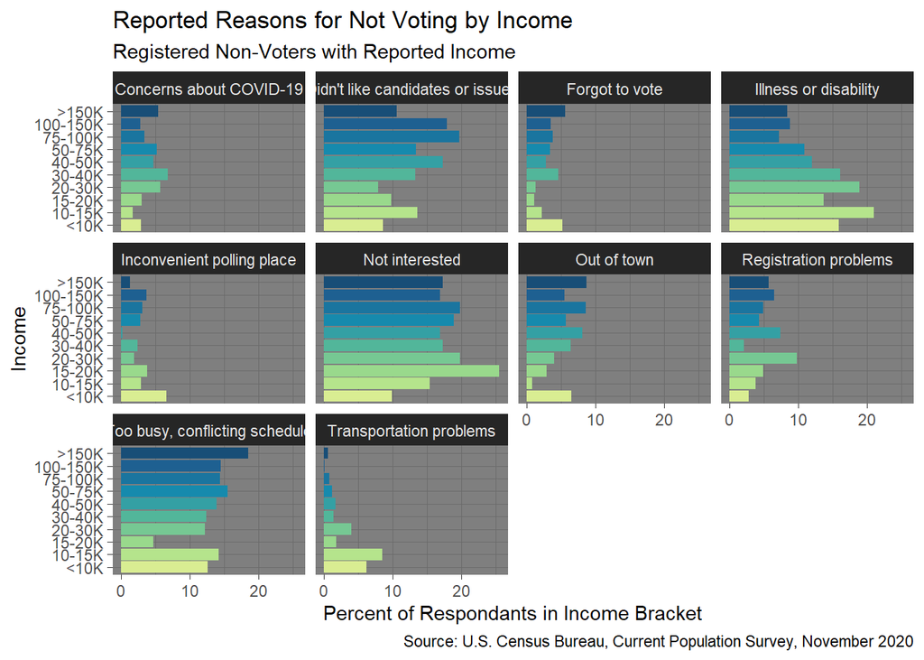

```r
# factor income levels
nonvoters_by_income$income <- factor(nonvoters_by_income$income,
                                     levels=c("<10K", "10-15K", "15-20K", "20-30K", "30-40K",
                                              "40-50K", "50-75K", "75-100K", "100-150K", ">150K"))

nonvoters_by_income %>%
  ggplot(aes(x=percent, y=income))+
  geom_col(aes(fill = income), show.legend = FALSE)+
  facet_wrap(~reason) +
  labs(title="Reported Reasons for Not Voting by Income",
       subtitle = "Registered Non-Voters with Reported Income",
       x="Percent of Respondants in Income Bracket", y="Income",
       caption="Source: U.S. Census Bureau, Current Population Survey, November 2020") +
  scale_fill_manual(values = palette10) +
  theme_dark()
```

*Figure 3*

## FiveThirtyEight Data

Read in and inspect data.

```r
voter_survey_538 <- read_csv("data/voter_survey_538_tidy.csv")

glimpse(voter_survey_538)
```

```
## Rows: 5,836
## Columns: 20
## $ Q3_4                    <dbl> 4, 3, 3, 4, 1, 2, 2, 1, 1, 2, 2, 4, 1, 1, 1, 1~
## $ Q3_5                    <dbl> 3, 3, 2, 2, 2, 2, 2, 1, 2, 3, 2, 3, 1, 1, 2, 2~
## $ Q5                      <dbl> 1, 1, 1, 1, 1, 2, 1, 1, 1, 1, 1, 1, 1, 2, 1, 1~
## $ Q16                     <dbl> 1, 2, 1, 4, 1, -1, 3, 1, 1, 3, 1, 2, 1, 1, 1, ~
## $ Q26                     <dbl> 1, 1, 1, 1, 1, 4, 1, 1, 1, 1, 1, 1, 4, 1, 1, 1~
## $ Q30                     <dbl> 2, 3, 2, 2, 1, 5, 1, 2, 1, 3, 1, 2, 1, 5, 1, 1~
## $ ppage                   <dbl> 73, 90, 53, 58, 81, 61, 80, 68, 70, 83, 43, 42~
## $ educ                    <chr> "College", "College", "College", "Some college~
## $ race                    <chr> "White", "White", "White", "Black", "White", "~
## $ gender                  <chr> "Female", "Female", "Male", "Female", "Male", ~
## $ income_cat              <chr> "$75-125k", "$125k or more", "$125k or more", ~
## $ voter_category          <chr> "always", "always", "sporadic", "sporadic", "a~
## $ pols_dont_care          <chr> "Somewhat Disagree", "Somewhat Disagree", "Som~
## $ media_greed             <chr> "Strongly Disagree", "Somewhat Disagree", "Som~
## $ election_results_matter <chr> "Who wins the Election really matters", "Who w~
## $ party                   <chr> "Democrat", "Independent", "Democrat", "Democr~
## $ vote_freq               <chr> "Always/Almost Always", "Always/Almost Always"~
## $ income_cat_coded        <dbl> 3, 4, 4, 2, 2, 2, 4, 3, 4, 4, 3, 4, 2, 4, 2, 3~
## $ voter_cat_coded         <dbl> 3, 3, 2, 2, 3, 1, 3, 3, 3, 3, 2, 2, 1, 2, 3, 2~
## $ educ_coded              <dbl> 3, 3, 3, 2, 1, 1, 1, 2, 3, 2, 3, 3, 3, 2, 1, 1~
```

Factor income, pols_dont_care, voter_category and education.

```r
voter_survey_538$income_cat <- factor(voter_survey_538$income_cat,
                                      levels = c("Less than $40k", "$40-75k",
                                                 "$75-125k", "$125k or more"))


voter_survey_538$pols_dont_care <- factor(voter_survey_538$pols_dont_care,
                                       levels = c("Strongly Disagree", "Somewhat Disagree",
                                                  "Somewhat Agree", "Strongly Agree"))


voter_survey_538$voter_category <- factor(voter_survey_538$voter_category,
                                      levels = c("always", "sporadic", "rarely/never"))


voter_survey_538$educ <- factor(voter_survey_538$educ,
                                      levels = c("High school or less", "Some college",
                                                 "College"))
```

### Voting Frequency and Income

In Figure 4, polling data confirm the trend we saw in Figure 1. People who make less than $40,000 or less yearly were roughly twice as likely to to vote rarely or never as people making $125,000 or more yearly. Additionally, people making more than $40,000 yearly were significantly more likely to always vote.

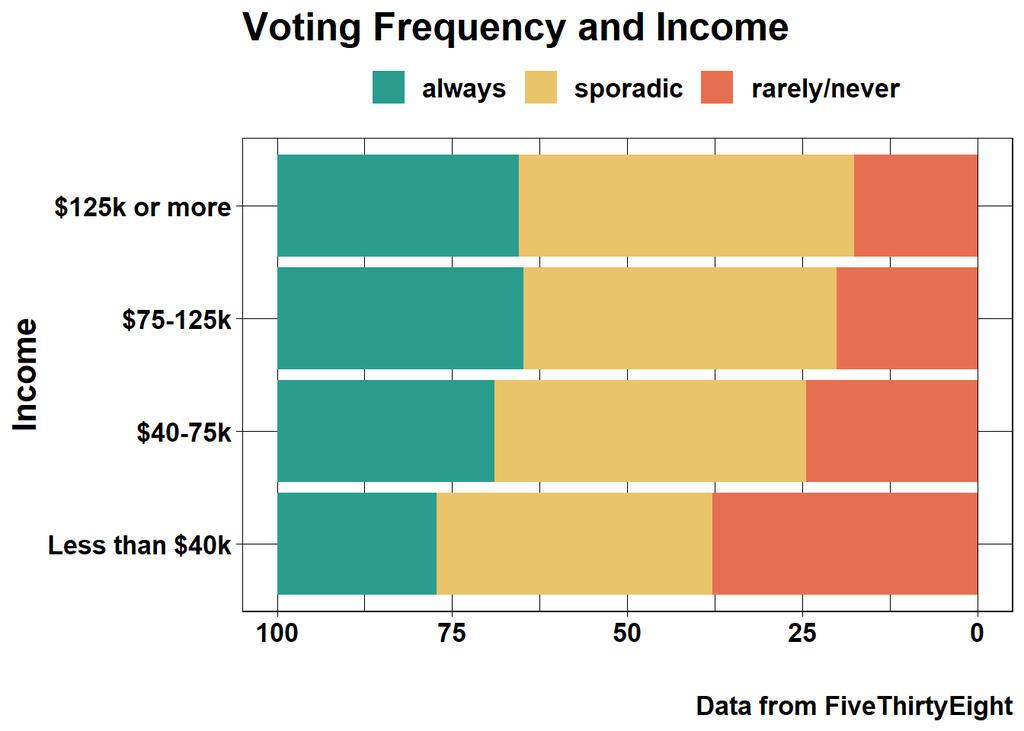

```r
vote_income_category <- voter_survey_538 %>%
  count(income_cat, voter_category) %>%
  group_by(income_cat) %>%
  mutate(income_percent = (n/sum(n))*100)

palette3 <- c("#2a9d8f", "#e9c46a", "#e76f51")

vote_income_category %>%
  filter(income_cat != "NA") %>%
  ggplot(aes(y = income_cat,
             x = income_percent)) +
  geom_col(aes(fill = voter_category)) +
  labs(title = "Voting Frequency and Income",
       x = '', y = 'Income', caption = "Data from FiveThirtyEight") +
  theme_linedraw() +
  scale_fill_manual(values = palette3) +
  theme(text = element_text(size = 16, face = "bold"),
        legend.title = element_blank(),
        legend.position = "top") +
  scale_x_reverse()
```

*Figure 4*

### Perception of Election Result Importance and Income

In Figure 5, at least 75% of respondents of all incomes agreed that the results of the 2020 election really mattered. However, instead agreeing that things would be pretty much the same, regardless became noticeably more common as income decreased.

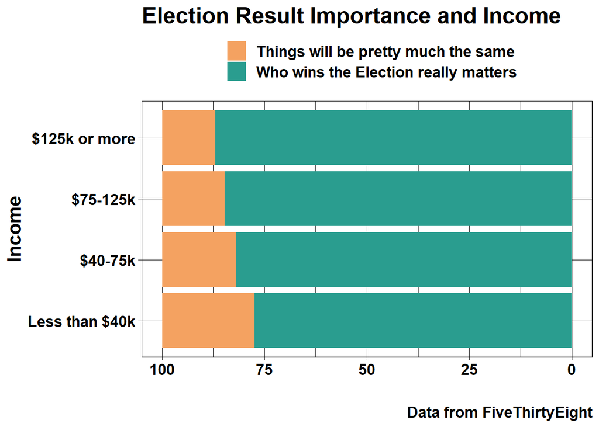

```r
# visualize "election results matter" by income
erm_by_income <- voter_survey_538  %>%
  filter(election_results_matter != "NA") %>%
  count(election_results_matter, income_cat) %>%
  group_by(income_cat) %>%
  mutate(income_cat_perc = (n/sum(n))*100)

palette2 <- c("#f4a261", "#2a9d8f")

erm_by_income %>%
  ggplot(aes(y = income_cat,
             x = income_cat_perc)) +
  geom_col(aes(fill = election_results_matter)) +
  theme_linedraw() +
  labs(title = "Election Result Importance and Income",
       x = '', y = 'Income', caption = "Data from FiveThirtyEight") +
  theme(text = element_text(size = 16, face = "bold"),
        legend.title = element_blank(),
        legend.position = "top") +
  guides(fill = guide_legend(ncol = 1)) +
  scale_x_reverse()  +
  scale_fill_manual(values = palette2)
```

*Figure 5*

### Perception of Importance to Political Entities and Income

In Figure 6, strongly agreeing with the statement “traditional parties and politicians don’t care about people like me” was more common among lower income people, while at least somewhat disagreeing with it was more common among higher income people. Notably, a large majority of people at all income levels at least somewhat agreed with that statement.

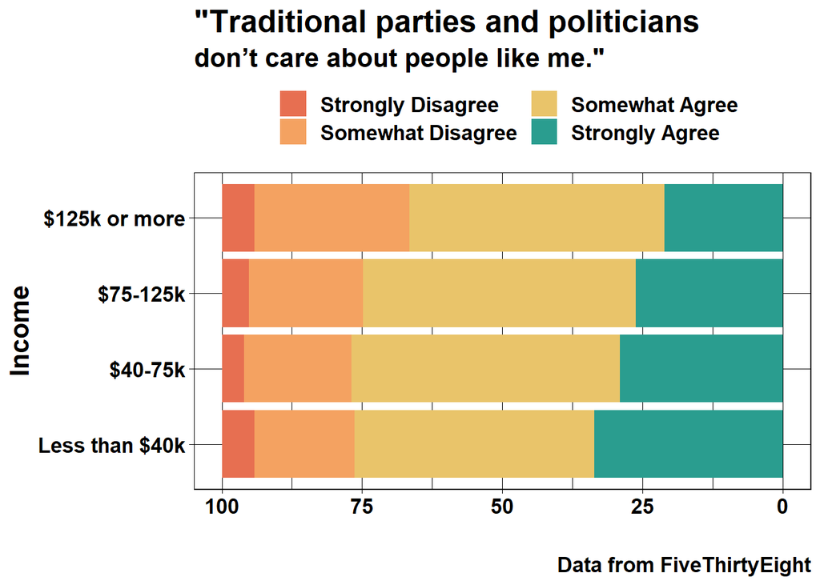

```r
pdc_by_income <- voter_survey_538 %>%
  filter(pols_dont_care != "NA") %>%
  count(pols_dont_care, income_cat) %>%
  group_by(income_cat) %>%
  mutate(income_cat_perc = (n/sum(n))*100)

palette4 <- c("#e76f51","#f4a261","#e9c46a","#2a9d8f")

pdc_by_income %>%
  ggplot(aes(y = income_cat,
             x = income_cat_perc)) +
  geom_col(aes(fill = factor(pols_dont_care))) +
  theme_linedraw() +
  labs(title = '"Traditional parties and politicians',
       subtitle = 'don’t care about people like me."',
       x = '', y = 'Income', caption = "Data from FiveThirtyEight") +
  scale_fill_manual(values = palette4) +
  theme(text = element_text(size = 16, face = "bold"),
        legend.title = element_blank(),
        legend.position = "top") +
  guides(fill = guide_legend(ncol = 2))+
  scale_x_reverse()
```

*Figure 6*

# Modeling

## Visualization

Figure 7 visualizes the relationship between income level, voting frequency and education. Because income and education are two aspects of class, which influences voting behavior, an analysis of the relationship between voting and income should check for interactions with education level. People with yearly income less than $40,000 were more likely to be classified as rarely or never voting, and more likely to have a high-school education or less. People making $75,000 or more were more likely to be classified as always voting, as well as more likely to be college-educated.

Most respondants to the FiveThirtyEight poll appear to be classified as sporadic voters, regardless of income level, which was also noticeable in Figure 4. FiveThirtyEight categorized respondents using the voting records matched to them. According to their Non-voters Codebook, sporadic voters “voted in at least two, but fewer than all-but-one of the elections they were eligible in.”

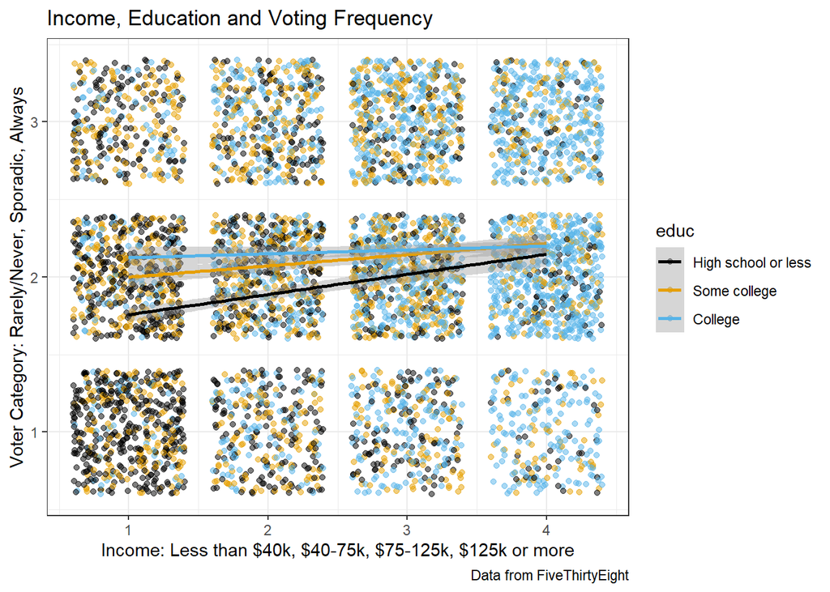

```r
v_labels <- c("Rarely/Never", "Sporadic", "Always")
i_labels <- c("Less than $40k", "$40-75k", "$75-125k", "$125k or more")

voter_survey_538 %>%
  ggplot(aes(x = income_cat_coded,
             y = voter_cat_coded,
             color = educ)) +
  geom_jitter(alpha = .5) +
  geom_smooth(method = lm) +
  theme(text = element_text(size = 18, face = "bold")) +
  labs(y = "Voter Category: Rarely/Never, Sporadic, Always",
       x = "Income: Less than $40k, $40-75k, $75-125k, $125k or more",
       title = "Income, Education and Voting Frequency",
       caption = "Data from FiveThirtyEight") +
  scale_color_colorblind() +
  theme_bw()
```

*Figure 7*

## Modeling

```r
income_votefreq_model <- lm(formula = voter_cat_coded ~ income_cat*educ,
                            data = voter_survey_538)

summary(income_votefreq_model)
```

```
##
## Call:
## lm(formula = voter_cat_coded ~ income_cat * educ, data = voter_survey_538)
##
## Residuals:
##      Min       1Q   Median       3Q      Max
## -1.20991 -0.20991 -0.09586  0.81971  1.27238
##
## Coefficients:
##                                          Estimate Std. Error t value Pr(>|t|)
## (Intercept)                               1.72762    0.02608  66.253  < 2e-16
## income_cat$40-75k                         0.23930    0.04141   5.779 7.88e-09
## income_cat$75-125k                        0.25238    0.04690   5.382 7.67e-08
## income_cat$125k or more                   0.38571    0.06500   5.934 3.12e-09
## educSome college                          0.24127    0.04315   5.592 2.35e-08
## educCollege                               0.34227    0.05949   5.754 9.18e-09
## income_cat$40-75k:educSome college       -0.11233    0.06368  -1.764  0.07776
## income_cat$75-125k:educSome college      -0.04123    0.06649  -0.620  0.53526
## income_cat$125k or more:educSome college -0.19253    0.08509  -2.263  0.02369
## income_cat$40-75k:educCollege            -0.15553    0.07636  -2.037  0.04170
## income_cat$75-125k:educCollege           -0.11236    0.07584  -1.482  0.13849
## income_cat$125k or more:educCollege      -0.27531    0.08741  -3.150  0.00164
##
## (Intercept)                              ***
## income_cat$40-75k                        ***
## income_cat$75-125k                       ***
## income_cat$125k or more                  ***
## educSome college                         ***
## educCollege                              ***
## income_cat$40-75k:educSome college       .
## income_cat$75-125k:educSome college
## income_cat$125k or more:educSome college *
## income_cat$40-75k:educCollege            *
## income_cat$75-125k:educCollege
## income_cat$125k or more:educCollege      **
## ---
## Signif. codes:  0 '***' 0.001 '**' 0.01 '*' 0.05 '.' 0.1 ' ' 1
##
## Residual standard error: 0.7292 on 5824 degrees of freedom
## Multiple R-squared:  0.04413,    Adjusted R-squared:  0.04233
## F-statistic: 24.44 on 11 and 5824 DF,  p-value: < 2.2e-16
```

Visualize effect of income and education on voter frequency.

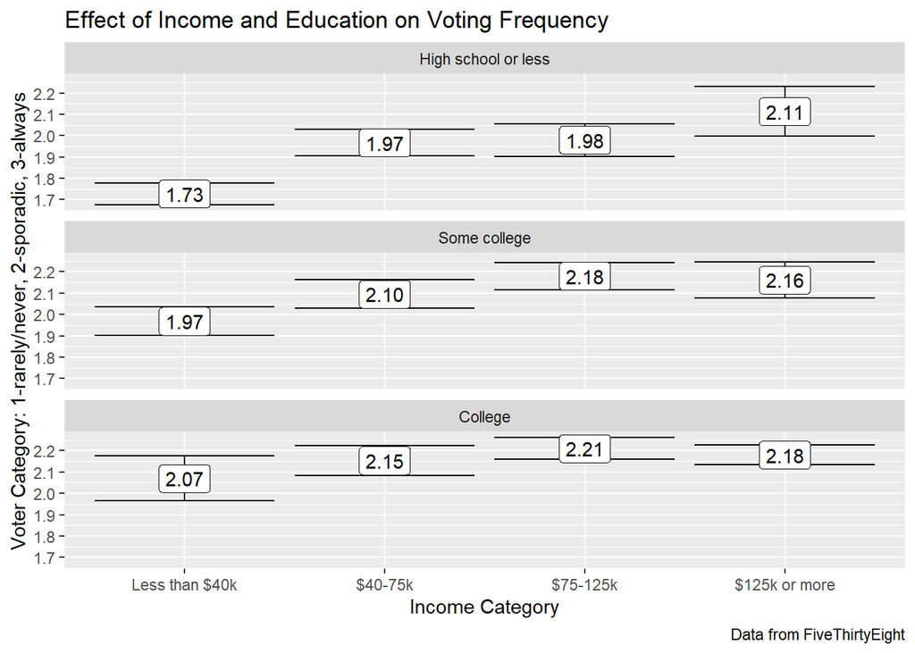

```r
effect("income_cat*educ", income_votefreq_model) %>%
  data.frame()  %>%
  ggplot(aes(x = reorder(income_cat, fit),
             y = fit,
             ymin = lower,
             ymax = upper,
             label = format(fit, digits = 3))) +
  geom_errorbar() +
  geom_label() +
  facet_wrap(~reorder(educ, lower), ncol = 1) +
  labs(y = "Voter Category: 1-rarely/never, 2-sporadic, 3-always",
       x = "Income Category",
       title = "Effect of Income and Education on Voting Frequency",
       caption = "Data from FiveThirtyEight")
```

*Figure 8*

## Interpretation

Income and voting frequency have a weak (r-squared: .042) but statistically significant (p < 2.2e-16) positive relationship, even when education is taken into account. Lower income people are less likely to vote frequently and vice versa. However, education level has a noticeable effect on voting frequency, and that effect becomes more pronounced as income decreases. College-educated people with lower incomes are significantly more likely to vote more frequently than their non-college educated counterparts. However, as income level increases, education appears to affect voting frequency less. People of all education levels have similar likelihood of voting if they are high income.

For context, it is important to note that people with higher income levels are more likely to have college educations. This is due to the high cost of higher education in the United States, which makes it far more accessible to wealthy people than to poor people. Additionally, people who live in low-income districts are less likely to receive a K-12 education that prepares them for college because school funding is based on local taxes. School districts where people have higher incomes and pay more taxes have more funding and better outcomes for their students, making it very difficult for poor districts to compete.

# Results

# Further References

- Census Data: https://www.census.gov/data/tables/time-series/demo/voting-and-registration/p20-585.html
- Explanation of Census Voting Data: https://www.census.gov/topics/public-sector/voting/about.html
- FiveThirtyEight Data: https://github.com/fivethirtyeight/data/tree/master/non-voters
- Explanation of FiveThirtyEight Data: https://github.com/fivethirtyeight/data/tree/master/non-voters#readme
- Original FiveThirtyEight story: https://projects.fivethirtyeight.com/non-voters-poll-2020-election/